# FIE5-2-IOS-4-Devoir-4

## Critère d’acceptabilité du planning

La consigne impose que tous les patients aient terminé leur prise en charge avant 20h. Nous retenons donc un critère strict d’acceptabilité du planning.

Un scénario est considéré comme acceptable si :

$$nbEntres = nbSortis$$

et

$$dernierDepart \leq 720$$

La première condition signifie que tous les patients générés ont terminé leur parcours. La seconde condition signifie que le dernier patient est sorti avant 20h, puisque le modèle commence à 8h et que 20h correspond à `t = 720` minutes.

Un scénario est donc rejeté si au moins un patient reste dans le système ou si le dernier départ a lieu après 20h.

Par exemple, un scénario donnant 93 entrées et 90 sorties n’est pas acceptable, car 3 patients restent encore dans le système. Ce résultat indique que les ressources du planning testé sont insuffisantes.

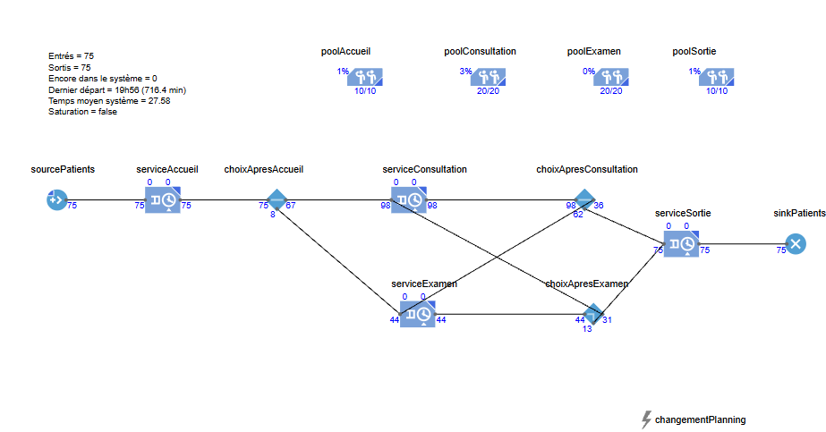

Capture du modèle AnyLogic avec entrées, sorties, temps moyen et saturation

## Résultats des scénarios testés

Nous avons testé plusieurs configurations de planning sur les deux tranches horaires `[8h ; 14h]` et `[14h ; 20h]`.

Le nombre moyen d’agents est calculé comme la moyenne des effectifs mobilisés sur les deux tranches. Dans les scénarios testés, les capacités sont indiquées sous la forme `matin / après-midi`.

```r
library(tibble)
library(knitr)

resultats_anylogic <- tibble::tribble(
  ~Scenario, ~Accueil, ~Consultation, ~Examen, ~Sortie, ~Agents_moyens,
  ~Entres, ~Sortis, ~Restants, ~Dernier_depart, ~Temps_moyen_systeme,
  ~Sature, ~Respect_20h, ~Acceptable,

  "A", "1/1", "1/1", "1/1", "1/1", 4.0,
  61, 61, 0, "2h48 (J+1)", 256.34,
  FALSE, FALSE, FALSE,

  "B", "1/1", "2/1", "1/1", "1/1", 4.5,
  66, 66, 0, "21h35", 89.50,
  FALSE, FALSE, FALSE,

  "C", "1/1", "2/2", "1/1", "1/1", 5.0,
  79, 79, 0, "19h24", 65.62,
  FALSE, TRUE, TRUE,

  "D", "1/1", "2/2", "2/1", "1/1", 5.5,
  72, 72, 0, "19h22", 37.44,
  FALSE, TRUE, TRUE,

  "E", "1/1", "2/2", "2/2", "1/1", 6.0,
  75, 75, 0, "19h56", 27.58,
  FALSE, TRUE, TRUE
)

knitr::kable(resultats_anylogic)
```

[output not shown]

Les scénarios A et B ne sont pas retenus. Même si tous les patients finissent par sortir du système, le dernier départ a lieu après 20h. Ces scénarios ne respectent donc pas la contrainte de fin de prise en charge avant 20h.

Le premier scénario respectant simultanément les deux conditions `nbEntres = nbSortis` et `dernierDepart <= 720` est le scénario C.

## Planning minimal retenu

Le planning minimal retenu est donc le scénario C.

| Activité | Matin | Après-midi |
| --- | --- | --- |
| Accueil | 1 | 1 |
| Consultation | 2 | 2 |
| Examen | 1 | 1 |
| Sortie | 1 | 1 |

Le nombre moyen d’agents mobilisés est donc :

$$1 + 2 + 1 + 1 = 5$$

Ce scénario est retenu comme planning minimal, car les scénarios avec moins d’agents ne permettent pas de respecter l’horaire de fin de prise en charge avant 20h.

Cependant, ce scénario reste relativement tendu. Le temps moyen passé dans le système est de 65,62 minutes. Cela signifie que, même si le système n’est pas saturé au sens strict, il reste sensible aux variations aléatoires des arrivées et des durées de service.

## Identification des goulets d’étranglement

L’activité Consultation constitue le principal point de passage du parcours patient. En effet, la majorité des patients y est orientée après l’accueil, et une partie des patients revient en consultation après un examen.

L’activité Examen constitue également un point sensible. Même si tous les patients ne passent pas par cette étape, le retour possible vers la consultation augmente la durée globale du parcours et peut créer des files d’attente supplémentaires.

Ainsi, les principaux goulets d’étranglement du modèle sont :

- la Consultation, car elle reçoit la majorité des patients ;
- l’Examen, car il peut provoquer un retour vers la Consultation ;
- l’enchaînement `Examen → Consultation`, qui augmente le temps total passé dans le système.

## Planning robuste proposé

Le planning minimal retenu est le scénario C. Toutefois, pour réduire le temps moyen passé dans le système et limiter les risques de saturation, nous proposons un planning légèrement plus robuste.

Le scénario E est retenu comme planning robuste :

| Activité | Matin | Après-midi |
| --- | --- | --- |
| Accueil | 1 | 1 |
| Consultation | 2 | 2 |
| Examen | 2 | 2 |
| Sortie | 1 | 1 |

Ce planning mobilise 6 agents en moyenne sur la journée, soit une ressource supplémentaire par rapport au planning minimal.

Il permet de réduire nettement le temps moyen passé dans le système :

| Scénario | Agents moyens | Dernier départ | Temps moyen dans le système | Acceptable |
| --- | --- | --- | --- | --- |
| C | 5.0 | 19h24 | 65.62 min | Oui |
| E | 6.0 | 19h56 | 27.58 min | Oui |

Le passage du scénario C au scénario E permet donc de réduire le temps moyen dans le système de :

$$65.62 - 27.58 = 38.04 \text{
minutes}$$

Cela correspond à une diminution d’environ :

$$\frac{38.04}{65.62} \times 100 \approx
58.0\%$$

Le scénario E constitue donc un planning plus robuste. Il respecte la contrainte de fin de prise en charge avant 20h, tout en réduisant fortement le temps moyen passé dans le système. Il apporte également une marge supplémentaire sur l’activité Examen, qui est l’un des points sensibles du parcours.

## Limites de l’analyse

Les résultats obtenus reposent sur des simulations stochastiques. Les arrivées des patients et les durées de service étant aléatoires, une seule simulation peut être influencée par l’aléa.

Pour fiabiliser la conclusion, il serait préférable de répéter chaque scénario plusieurs fois, par exemple 30 ou 50 réplications, puis de comparer :

- le nombre moyen de patients sortis ;
- le dernier départ moyen ;
- le temps moyen passé dans le système ;
- l’attente moyenne ;
- le taux d’occupation moyen des ressources.

Cette analyse par réplications permettrait de vérifier que le scénario retenu reste acceptable dans la majorité des cas, et pas seulement pour une seule réalisation aléatoire.

## Conclusion de la Question 3

Le modèle AnyLogic construit à partir des circuits patients de la Question 1 permet de tester différents plannings d’agents sur les deux tranches horaires `[8h ; 14h]` et `[14h ; 20h]`.

Afin de rendre compatible la contrainte de fin de prise en charge avant 20h avec les temps de service observés, nous avons introduit une fermeture des admissions à 19h. Cette hypothèse est nécessaire, car un patient arrivant trop tardivement ne peut pas terminer instantanément son parcours, même en présence de ressources disponibles.

Le planning minimal acceptable est le scénario C, avec 5 agents en moyenne sur la journée :

| Activité | Matin | Après-midi |
| --- | --- | --- |
| Accueil | 1 | 1 |
| Consultation | 2 | 2 |
| Examen | 1 | 1 |
| Sortie | 1 | 1 |

Le planning robuste proposé est le scénario E, avec 6 agents en moyenne :

| Activité | Matin | Après-midi |
| --- | --- | --- |
| Accueil | 1 | 1 |
| Consultation | 2 | 2 |
| Examen | 2 | 2 |
| Sortie | 1 | 1 |

Le scénario E est préférable si l’objectif est de réduire significativement le temps moyen de passage et de limiter les risques de saturation liés aux goulets d’étranglement du parcours patient.

### Discussion supplémentaire (points complémentaires sur chaque question)

Pour chaque question, comparez les résultats de simulation à la réalité observée dans les données, en quantifiant les écarts et en identifiant leurs causes possibles.

### Soutenance (/10)

Préparez une **présentation orale de 15 minutes** exposant votre démarche, vos résultats et vos analyses, pour le **21/05/2026**.